# Analyse des Correspondances

Jeu de données tableau_contingence_no_iso

Ce jeu de données contient 244 lignes et 7 colonnes.

### 1. Observation d’individus extrêmes

La détection des individus extrêmes ne s’applique pas à l’AFC.

### 2. Distribution de l’inertie

L’inertie des axes factoriels indique d’une part si les variables sont structurées et suggère d’autre part le nombre judicieux de composantes principales à étudier.

Les 2 premiers axes de l’ analyse expriment **68.83%** de l’inertie totale du jeu de données ; cela signifie que 68.83% de la variabilité totale du nuage des lignes (ou des colonnes) est représentée dans ce plan. C’est un pourcentage assez important, et le premier plan représente donc convenablement la variabilité contenue dans une grande part du jeu de données actif. Cette valeur est nettement supérieure à la valeur référence de **41.57%**, la variabilité expliquée par ce plan est donc hautement significative (cette intertie de référence est le quantile 0.95-quantile de la distribution des pourcentages d’inertie obtenue en simulant 872 jeux de données aléatoires de dimensions comparables sur la base d’une distribution uniforme).

Du fait de ces observations, il serait tout de même probablement préférable de considérer également dans l’analyse les dimensions supérieures ou égales à la troisième.

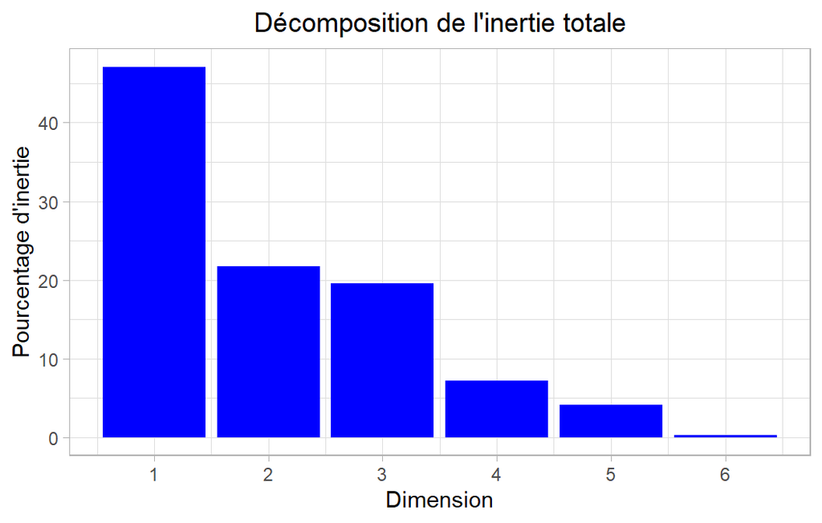

**Figure 2 - Décomposition de l’inertie totale**

Une estimation du nombre pertinent d’axes à interpréter suggère de restreindre l’analyse à la description des 3 premiers axes. Ces composantes révèlent un taux d’inertie supérieur à celle du quantile 0.95-quantile de distributions aléatoires (88.42% contre 58.89%). Cette observation suggère que seuls ces axes sont porteurs d’une véritable information. En conséquence, la description de l’analyse sera restreinte à ces seuls axes.

### 3. Description du plan 1:2

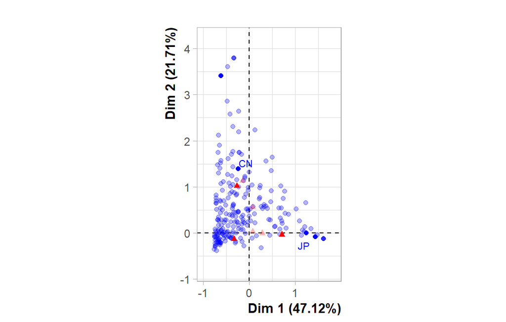

**Figure 3.1 - Graphe superposé (AFC)** *Les lignes libellées sont celles ayant la plus grande contribution à la construction du plan.* *Les colonnes libellées sont celles les mieux représentées sur le plan.*

Le groupe auquel les facteurs *JP* et *KR* appartiennent (caractérisés par une coordonnée positive sur l’axe) partage :

- une forte fréquence des modalités *heliport*, *seaplane_base* et *balloonport* (du plus commun au plus rare).

Le groupe 2 (caractérisés par une coordonnées négative sur l’axe) partage :

- high frequency for the variable *small_airport*.

Le groupe 3 (caractérisés par une coordonnées négative sur l’axe) partage :

- des modalité dont la fréquence ne diffèrent pas significativement de la moyenne.

La **dimension 2** oppose des facteurs tels que *CN* (en haut du graphe, caractérisés par une coordonnées fortement positive sur l’axe) à des facteurs comme *JP* et *KR* (en bas du graphe, caractérisés par une coordonnées fortement négative sur l’axe).

Le groupe auquel le facteur *CN* appartient (caractérisés par une coordonnée positive sur l’axe) partage :

- low frequency for the variable *small_airport*.

Le groupe 2 (caractérisés par une coordonnée positive sur l’axe) partage :

- des modalité dont la fréquence ne diffèrent pas significativement de la moyenne.

Le groupe 3 (caractérisés par une coordonnées négative sur l’axe) partage :

- high frequency for the variable *small_airport*.

Le groupe auquel les facteurs *JP* et *KR* appartiennent (caractérisés par une coordonnées négative sur l’axe) partage :

- une forte fréquence des modalités *heliport*, *seaplane_base* et *balloonport* (du plus commun au plus rare).

### 4. Description de la dimension 3

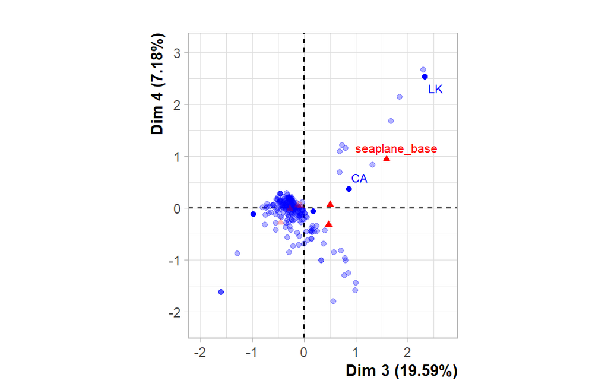

**Figure 4.1 - Graphe superposé (AFC)** *Les lignes libellées sont celles ayant la plus grande contribution à la construction du plan.* *Les colonnes libellées sont celles les mieux représentées sur le plan.*

Le groupe 1 (caractérisés par une coordonnée positive sur l’axe) partage :

- des modalité dont la fréquence ne diffèrent pas significativement de la moyenne.

Le groupe auquel le facteur *CA* appartient (caractérisés par une coordonnée positive sur l’axe) partage :

- des modalité dont la fréquence ne diffèrent pas significativement de la moyenne.

Le groupe auquel le facteur *LK* appartient (caractérisés par une coordonnée positive sur l’axe) partage :

- des modalité dont la fréquence ne diffèrent pas significativement de la moyenne.

Le groupe 4 (caractérisés par une coordonnées négative sur l’axe) partage :

- des modalité dont la fréquence ne diffèrent pas significativement de la moyenne.